# Análisis territorial de las predicciones COM

Desempeño del modelo logístico reducido D-2 por CCZ

## 1 Resumen ejecutivo

Este informe evalúa si el modelo global de reclamos COM mantiene un desempeño comparable entre los Centros Comunales Zonales (CCZ). No se entrenó un modelo por CCZ y el territorio no se utilizó como predictor: se aplicó el mismo modelo a toda la ciudad y luego se desagregaron sus resultados.

Resultados principales:

- el cruce territorial tiene cobertura completa en los 18 CCZ;
- el AUC global es 0,753 en validación y 0,753 en test;
- el AUC por CCZ varía entre 0,691 y 0,771 en validación, y entre 0,691 y 0,760 en test;
- la calibración también presenta diferencias territoriales;
- el ranking global de ciudad y el ranking local dentro de cada CCZ representan políticas operativas diferentes.

El modelo conserva capacidad de discriminación en todos los CCZ, pero su magnitud y calibración no son uniformes. Estas diferencias describen el target COM y no constituyen por sí solas evidencia de diferencias en problemas físicos.

## 2 Pregunta y dimensiones de evaluación

El modelo estima, para cada `cluster_id` y día, la probabilidad de que exista al menos un reclamo COM válido. La pregunta es si el mismo modelo global ordena y calibra adecuadamente ese riesgo en los distintos CCZ y cómo distribuye su priorización territorial.

Se distinguen tres dimensiones:

1. **Discriminación:** ordenamiento de cluster-días con y sin reclamo dentro de cada CCZ.
2. **Calibración:** correspondencia entre probabilidad predicha y tasa observada.
3. **Utilidad operativa:** captura bajo un ranking global de ciudad y bajo rankings locales por CCZ.

## 3 Modelo y cortes temporales

Se evaluó el modelo logístico reducido COM con historia cerrada hasta `D-2`. Las predicciones fueron reconstruidas desde el modelo y la preparación guardados, sin reentrenamiento. Se conservaron sus splits temporales originales.

Configuración del diagnóstico

| Versión de clusters | Rezago COM | Meses de validación | Meses de test | Remuestreos bootstrap |
| --- | --- | --- | --- | --- |
| v2026_05_25 | D-2 | 202601,202602,202603 | 202604,202605 | 1000 |

Cada cluster se cruzó con la capa administrativa mediante `version_cluster`/`cluster_id`. El CCZ se usó exclusivamente para auditar las predicciones.

## 4 Cobertura territorial

Cobertura de las predicciones

| Split | Filas | Clusters | Días | Positivos | CCZ | Filas sin CCZ | Clusters sin CCZ |
| --- | --- | --- | --- | --- | --- | --- | --- |
| Validación | 736.041 | 8.482 | 90 | 73.449 | 18 | 0 | 0 |
| Test | 427.999 | 8.131 | 54 | 47.631 | 18 | 0 | 0 |

No se observaron predicciones sin CCZ ni duplicaciones de la clave territorial.

## 5 Desempeño global

Métricas globales reconstruidas

| Split | N | Positivos | Prevalencia | Predicción media | AUC | Logloss | Brier |
| --- | --- | --- | --- | --- | --- | --- | --- |
| Validación | 736.041 | 73.449 | 10,0% | 10,9% | 0,753 | 0,288 | 0,082 |
| Test | 427.999 | 47.631 | 11,1% | 11,4% | 0,753 | 0,308 | 0,090 |

Estas métricas coinciden, salvo diferencias numéricas despreciables, con las salidas originales del modelo. Esto valida la reconstrucción usada para la desagregación territorial.

## 6 Discriminación por CCZ

El AUC se calcula usando únicamente predicciones y observados del mismo CCZ. Un AUC alto indica que, dentro de ese territorio, los cluster-días con reclamo tienden a recibir mayor score.

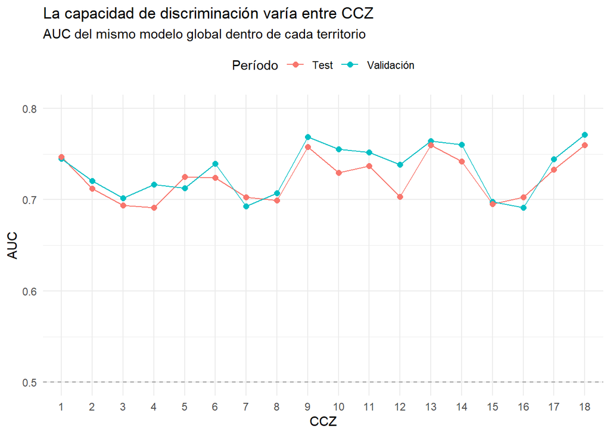

Desempeño por CCZ en test

| CCZ | Clusters | Positivos | Prevalencia | AUC | Logloss | Brier |
| --- | --- | --- | --- | --- | --- | --- |
| 4 | 222 | 2.150 | 18,0% | 0,691 | 0,436 | 0,137 |
| 3 | 619 | 5.291 | 16,0% | 0,694 | 0,408 | 0,126 |
| 15 | 250 | 1.751 | 13,2% | 0,695 | 0,361 | 0,108 |
| 8 | 389 | 2.029 | 10,1% | 0,699 | 0,305 | 0,087 |
| 16 | 258 | 1.651 | 12,1% | 0,703 | 0,340 | 0,099 |
| 7 | 392 | 3.432 | 16,3% | 0,703 | 0,411 | 0,128 |
| 12 | 404 | 1.178 | 5,5% | 0,703 | 0,206 | 0,051 |
| 2 | 466 | 5.163 | 20,8% | 0,712 | 0,466 | 0,150 |
| 6 | 303 | 2.243 | 14,0% | 0,724 | 0,368 | 0,111 |
| 5 | 515 | 4.864 | 17,6% | 0,725 | 0,419 | 0,131 |
| 10 | 209 | 503 | 4,5% | 0,729 | 0,178 | 0,044 |
| 17 | 365 | 1.037 | 5,4% | 0,733 | 0,195 | 0,049 |
| 11 | 862 | 4.709 | 10,4% | 0,737 | 0,300 | 0,086 |
| 14 | 585 | 2.823 | 10,0% | 0,742 | 0,290 | 0,083 |
| 1 | 239 | 1.855 | 15,1% | 0,747 | 0,375 | 0,114 |
| 9 | 1.111 | 3.613 | 6,2% | 0,758 | 0,210 | 0,055 |
| 18 | 194 | 271 | 2,6% | 0,760 | 0,118 | 0,026 |
| 13 | 748 | 3.068 | 7,7% | 0,760 | 0,243 | 0,067 |

El AUC debe leerse junto con prevalencia, calibración y volumen. Un CCZ con menor AUC no necesariamente tiene menor precisión o menos reclamos.

## 7 Incertidumbre temporal

Se calcularon métricas diarias por CCZ y se remuestrearon días completos 1.000 veces. Los intervalos siguientes corresponden a la **media diaria** del AUC, no al AUC agrupado de toda la ventana.

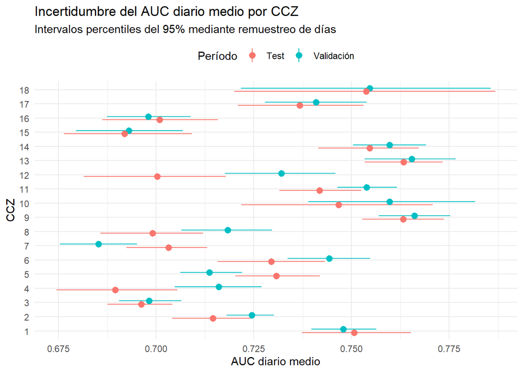

Los intervalos no deben utilizarse como una clasificación automática de territorios “buenos” y “malos”, especialmente por las múltiples comparaciones.

## 8 Calibración territorial

La calibración compara el riesgo medio predicho con la tasa observada. Por encima de la diagonal hay más reclamos que los predichos; por debajo, el modelo predice más riesgo que el observado.

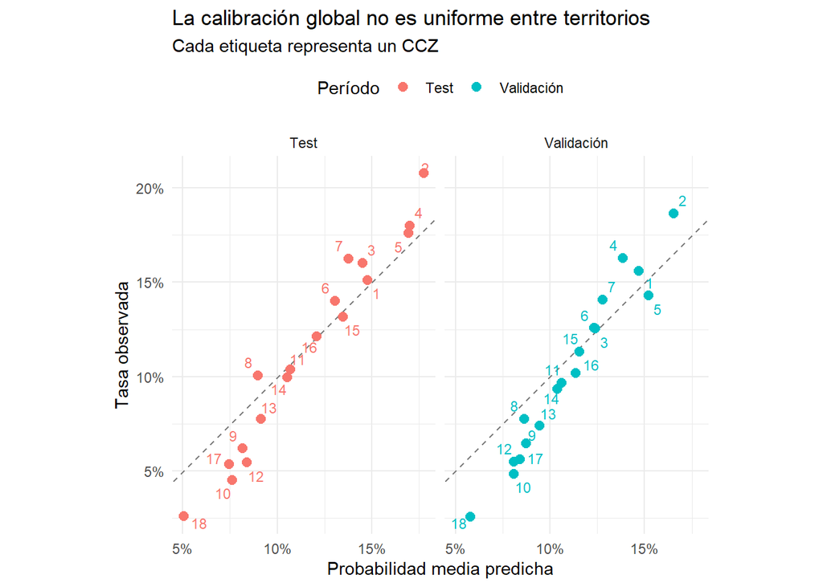

Calibración territorial en test

| CCZ | Tasa observada | Predicción media | Predicción - observado | Observado / esperado |
| --- | --- | --- | --- | --- |
| 2 | 20,8% | 17,7% | -3,0% | 1,17 |
| 7 | 16,3% | 13,8% | -2,5% | 1,18 |
| 3 | 16,0% | 14,5% | -1,5% | 1,10 |
| 8 | 10,1% | 9,0% | -1,1% | 1,12 |
| 4 | 18,0% | 17,0% | -1,0% | 1,06 |
| 6 | 14,0% | 13,0% | -1,0% | 1,07 |
| 5 | 17,6% | 16,9% | -0,7% | 1,04 |
| 1 | 15,1% | 14,8% | -0,3% | 1,02 |
| 16 | 12,1% | 12,1% | -0,1% | 1,01 |
| 15 | 13,2% | 13,5% | 0,3% | 0,98 |
| 11 | 10,4% | 10,7% | 0,3% | 0,97 |
| 14 | 10,0% | 10,5% | 0,6% | 0,95 |
| 13 | 7,7% | 9,1% | 1,4% | 0,85 |
| 9 | 6,2% | 8,2% | 2,0% | 0,76 |
| 17 | 5,4% | 7,4% | 2,1% | 0,72 |
| 18 | 2,6% | 5,1% | 2,5% | 0,51 |
| 12 | 5,5% | 8,4% | 2,9% | 0,65 |
| 10 | 4,5% | 7,6% | 3,1% | 0,60 |

La salida `calibracion_ccz_bandas.csv` complementa esta lectura con cinco bandas globales de score compartidas entre territorios.

## 9 Ranking global y ranking local

Se evaluaron dos políticas:

- **Global:** seleccionar diariamente el top 5%, 10% o 20% de toda la ciudad.
- **Local:** seleccionar esos porcentajes dentro de cada CCZ, reservando una capacidad territorial proporcional.

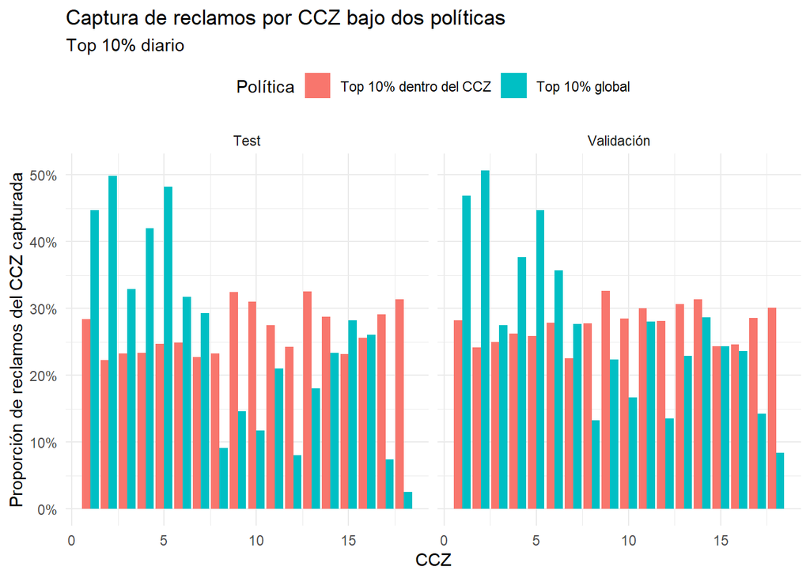

Ranking global y local por CCZ en test, top 10% diario

| CCZ | Politica | Clusters | N cluster-día | Peso en universo | Seleccionados | Peso dentro del top | Tasa de selección | Prevalencia | Precisión | Captura | Lift | Representación relativa |
| --- | --- | --- | --- | --- | --- | --- | --- | --- | --- | --- | --- | --- |
| 1 | Global | 239 | 12.273 | 2,9% | 2.291 | 5,4% | 18,7% | 15,1% | 36,2% | 44,7% | 2,39 | 1,87 |
| 1 | Local | 239 | 12.273 | 2,9% | 1.215 | 2,9% | 9,9% | 15,1% | 43,4% | 28,4% | 2,87 | 1,00 |
| 2 | Global | 466 | 24.864 | 5,8% | 6.876 | 16,1% | 27,7% | 20,8% | 37,4% | 49,8% | 1,80 | 2,77 |
| 2 | Local | 466 | 24.864 | 5,8% | 2.458 | 5,8% | 9,9% | 20,8% | 46,7% | 22,3% | 2,25 | 1,00 |
| 3 | Global | 619 | 33.028 | 7,7% | 5.130 | 12,0% | 15,5% | 16,0% | 34,0% | 32,9% | 2,12 | 1,55 |
| 3 | Local | 619 | 33.028 | 7,7% | 3.271 | 7,7% | 9,9% | 16,0% | 37,6% | 23,2% | 2,35 | 1,00 |
| 4 | Global | 222 | 11.952 | 2,8% | 2.609 | 6,1% | 21,8% | 18,0% | 34,6% | 42,0% | 1,92 | 2,18 |
| 4 | Local | 222 | 11.952 | 2,8% | 1.184 | 2,8% | 9,9% | 18,0% | 42,5% | 23,4% | 2,36 | 1,00 |
| 5 | Global | 515 | 27.636 | 6,5% | 6.477 | 15,1% | 23,4% | 17,6% | 36,2% | 48,3% | 2,06 | 2,34 |
| 5 | Local | 515 | 27.636 | 6,5% | 2.745 | 6,5% | 9,9% | 17,6% | 43,9% | 24,8% | 2,49 | 1,00 |
| 6 | Global | 303 | 16.015 | 3,7% | 2.113 | 4,9% | 13,2% | 14,0% | 33,7% | 31,8% | 2,41 | 1,32 |
| 6 | Local | 303 | 16.015 | 3,7% | 1.571 | 3,7% | 9,8% | 14,0% | 35,5% | 24,9% | 2,54 | 0,99 |
| 7 | Global | 392 | 21.114 | 4,9% | 2.852 | 6,7% | 13,5% | 16,3% | 35,3% | 29,3% | 2,17 | 1,35 |
| 7 | Local | 392 | 21.114 | 4,9% | 2.103 | 5,0% | 10,0% | 16,3% | 37,1% | 22,8% | 2,28 | 1,00 |
| 8 | Global | 389 | 20.145 | 4,7% | 653 | 1,5% | 3,2% | 10,1% | 28,3% | 9,1% | 2,81 | 0,32 |
| 8 | Local | 389 | 20.145 | 4,7% | 1.995 | 4,7% | 9,9% | 10,1% | 23,7% | 23,3% | 2,35 | 1,00 |
| 9 | Global | 1.111 | 58.333 | 13,6% | 2.005 | 4,7% | 3,4% | 6,2% | 26,3% | 14,6% | 4,24 | 0,34 |
| 9 | Local | 1.111 | 58.333 | 13,6% | 5.809 | 13,7% | 10,0% | 6,2% | 20,2% | 32,4% | 3,26 | 1,00 |
| 10 | Global | 209 | 11.092 | 2,6% | 328 | 0,8% | 3,0% | 4,5% | 18,0% | 11,7% | 3,97 | 0,30 |
| 10 | Local | 209 | 11.092 | 2,6% | 1.080 | 2,5% | 9,7% | 4,5% | 14,4% | 31,0% | 3,19 | 0,98 |
| 11 | Global | 862 | 45.367 | 10,6% | 3.328 | 7,8% | 7,3% | 10,4% | 29,8% | 21,1% | 2,87 | 0,73 |
| 11 | Local | 862 | 45.367 | 10,6% | 4.518 | 10,7% | 10,0% | 10,4% | 28,6% | 27,5% | 2,76 | 1,00 |
| 12 | Global | 404 | 21.573 | 5,0% | 518 | 1,2% | 2,4% | 5,5% | 18,3% | 8,1% | 3,36 | 0,24 |
| 12 | Local | 404 | 21.573 | 5,0% | 2.125 | 5,0% | 9,9% | 5,5% | 13,5% | 24,3% | 2,46 | 0,99 |
| 13 | Global | 748 | 39.608 | 9,3% | 1.925 | 4,5% | 4,9% | 7,7% | 28,7% | 18,0% | 3,71 | 0,49 |
| 13 | Local | 748 | 39.608 | 9,3% | 3.942 | 9,3% | 10,0% | 7,7% | 25,4% | 32,6% | 3,27 | 1,00 |
| 14 | Global | 585 | 28.356 | 6,6% | 2.210 | 5,2% | 7,8% | 10,0% | 29,9% | 23,4% | 3,00 | 0,78 |
| 14 | Local | 585 | 28.356 | 6,6% | 2.821 | 6,7% | 9,9% | 10,0% | 28,8% | 28,8% | 2,89 | 1,00 |
| 15 | Global | 250 | 13.292 | 3,1% | 1.661 | 3,9% | 12,5% | 13,2% | 29,7% | 28,2% | 2,26 | 1,25 |
| 15 | Local | 250 | 13.292 | 3,1% | 1.296 | 3,1% | 9,8% | 13,2% | 31,3% | 23,2% | 2,38 | 0,98 |
| 16 | Global | 258 | 13.608 | 3,2% | 1.400 | 3,3% | 10,3% | 12,1% | 30,7% | 26,0% | 2,53 | 1,03 |
| 16 | Local | 258 | 13.608 | 3,2% | 1.350 | 3,2% | 9,9% | 12,1% | 31,3% | 25,6% | 2,58 | 1,00 |
| 17 | Global | 365 | 19.306 | 4,5% | 319 | 0,7% | 1,7% | 5,4% | 24,1% | 7,4% | 4,49 | 0,17 |
| 17 | Local | 365 | 19.306 | 4,5% | 1.912 | 4,5% | 9,9% | 5,4% | 15,8% | 29,1% | 2,94 | 1,00 |
| 18 | Global | 194 | 10.437 | 2,4% | 83 | 0,2% | 0,8% | 2,6% | 8,4% | 2,6% | 3,25 | 0,08 |
| 18 | Local | 194 | 10.437 | 2,4% | 1.026 | 2,4% | 9,8% | 2,6% | 8,3% | 31,4% | 3,19 | 0,99 |

`Clusters` cuenta identificadores distintos y `N cluster-día` mide la exposición acumulada durante test. El peso territorial se calcula con cluster-días porque el ranking y la selección se realizan diariamente.

La representación relativa compara el peso del CCZ dentro del top con su peso en el universo:

```
representación relativa = peso dentro del top / peso en el universo
```

Esto equivale a dividir la tasa de selección del CCZ por la tasa de selección global, cercana al 10% en esta tabla. Un valor mayor que 1 indica sobrerrepresentación. En el ranking local queda cercano a 1 por construcción.

La prevalencia se muestra para hacer auditable el lift:

```
lift = precisión / prevalencia del CCZ
```

La captura es la proporción de cluster-días positivos del CCZ que quedó dentro de la selección diaria.

El ranking global busca maximizar la priorización conjunta según el score; el local garantiza presencia territorial. La elección depende del objetivo y de las restricciones operativas.

## 10 Estabilidad mensual

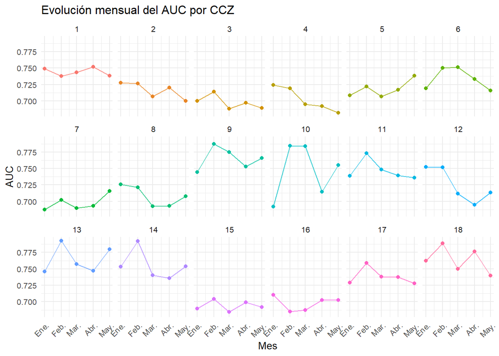

La ventana de test contiene solo dos meses. Su estabilidad mensual debe leerse como confirmación acotada, no como evidencia de largo plazo.

## 11 Límites de interpretación

El target `tuvo_reclamo` mide reclamos COM observados. Una diferencia entre CCZ puede combinar frecuencia real de problemas, exposición, composición de contenedores, historia de reclamos, propensión territorial a reclamar y desempeño propio del modelo.

Este análisis permite afirmar dónde el modelo predice y prioriza mejor los **reclamos COM**, pero no dónde existen más problemas físicos ni si hay equidad territorial. Zona Limpia ofrece una fuente complementaria para estudiar problemas observados sin reclamo y debe analizarse por separado.

## 12 Conclusiones

1. El modelo global mantiene discriminación en los 18 CCZ, pero el desempeño no es homogéneo.
2. Un buen AUC territorial no garantiza buena calibración.
3. La composición territorial depende de si se adopta ranking global o local.
4. Antes de modificar el modelo conviene confirmar los patrones en nuevas ventanas y contrastarlos con diferencias en propensión de reclamo.
5. Si una descalibración persiste, el siguiente experimento razonable sería una recalibración aprendida fuera de test, no 18 modelos independientes.

## 13 Reproducibilidad

El diagnóstico se genera mediante:

- `scripts/diagnostico_territorial_modelo_com_ccz.R`;
- modelo `logistico_cluster_dia_reducido_reclamos_d2`;
- capa `cluster_admin_territorial`;
- salidas en `outputs/diagnostico_territorial_modelo_com_ccz/`.